# Stars 2

Walter Humberto Subiza Pina

12/5/2020

## Manipulación de objetos stars raster y vectoriales - ANEXO

### Otras herramientas de extracción de datos

Con la imagen de los documentos anteriores , veremos otras formas de seleccionar y cortar datos específicos.

```r
library(stars)
```

Cargar la imagen…

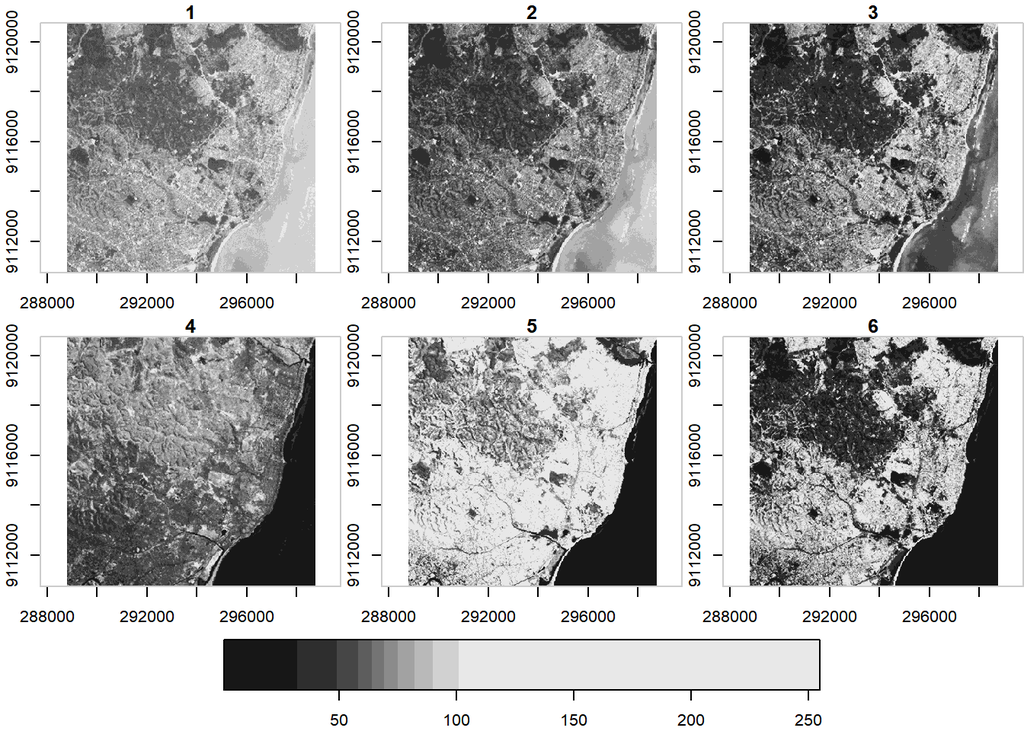

```r
tif = system.file("tif/L7_ETMs.tif", package = "stars")# creacion del camino del archivo como objeto texto

img = read_stars(tif) # lectura del archivo

plot(img, axes = T) # visualizer las 6 bandas
```

Polígono de corte…

```r
# 1
pt1 = st_point(c(290000, 9119000))
pt2 = st_point(c(293000, 9119000))
pt3 = st_point(c(293000, 9116000))
pt4 = st_point(c(290000, 9116000))
pt5 = st_point(c(290000, 9119000)) # punto de cierre, igual al pt1
# 2
pol <-st_polygon(list(rbind(pt1, pt2, pt3, pt4, pt5)))
# 3
pol <- st_sfc(pol, crs = st_crs(img))
```

Extracción usando la función *sf::st_crop()*. Fue colocado en el fragmento de código siguiente el polígono ya definido anteriormente. Esta función solo puede ser usada con formas rectangulares.

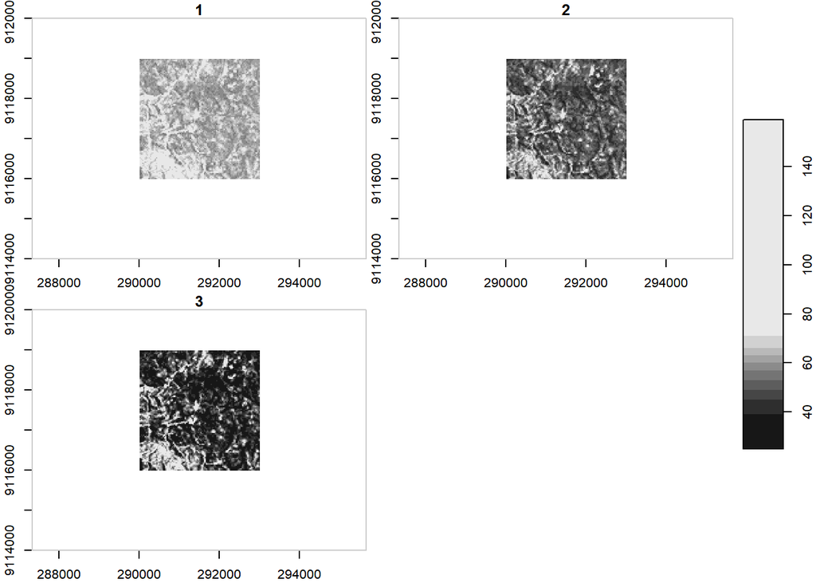

```r
p <- st_crop(img[, , , 1:3], pol)

plot(p, axes = T,
      xlim = c(289000, 294000),
      ylim = c(9114000, 9120000))
```

La función *stars::cut* corta la imagen, clasificando los valores en categorias, por exemplo, en el fragmento de código que sigue vamos a clasificar cada banda en tres categorias: valores de pixel entre 0 y 50, entre 50 y 100, y finalmente entre 100 y 255. Esta función pode ser útil en caso de querer extraer o eliminar valores determinados del atributo.

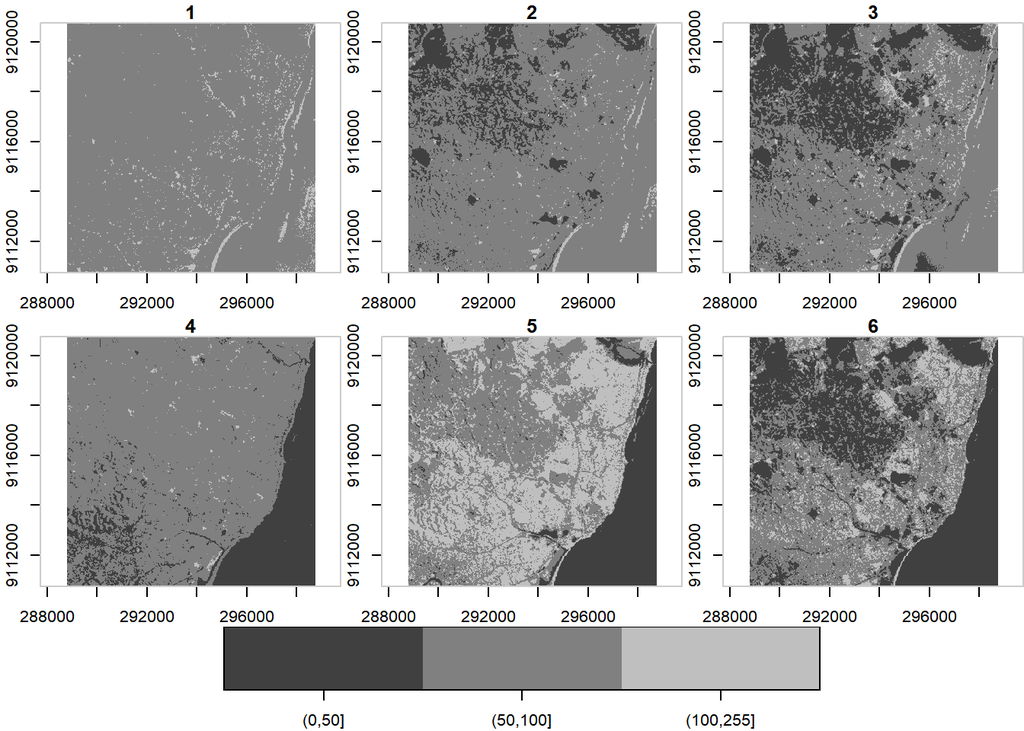

```r
img_corte3 <- cut(img, c(0, 50, 100, 255))

plot(img_corte3, axes =T )
```

Al usar el paréntesis recto, podemos especificar capas e localizaciones específicas. Notese que vamos eliminar todos los valores de células inferiores a 50, establecer una nueva clasificación en una zona y capas específicas.

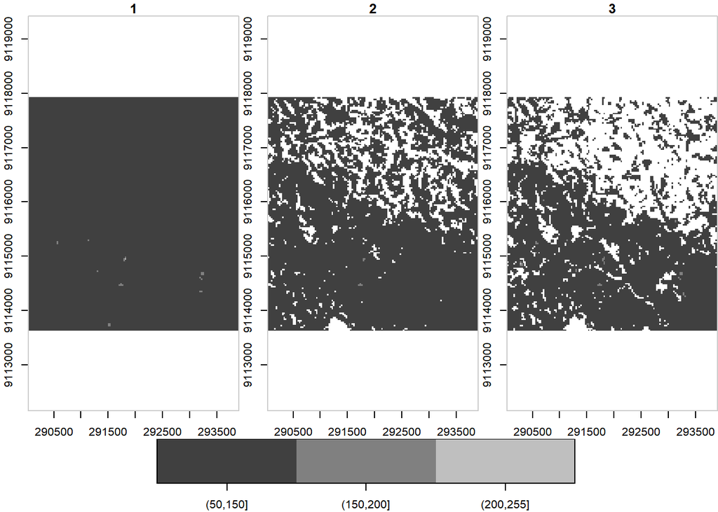

```r
img_corte3 <- cut(img[1 ,45:180 , 100:250 , 1:3], c(50, 150, 200, 255))

plot(img_corte3, axes =T )
```

Otra función que puede ser útil es *dplyr::slice()*, que también permite extraer por ejemplo, bandas o valores determinados de cada dimensión.

Primer ejemplo, extracción de las bandas 1 a 3.

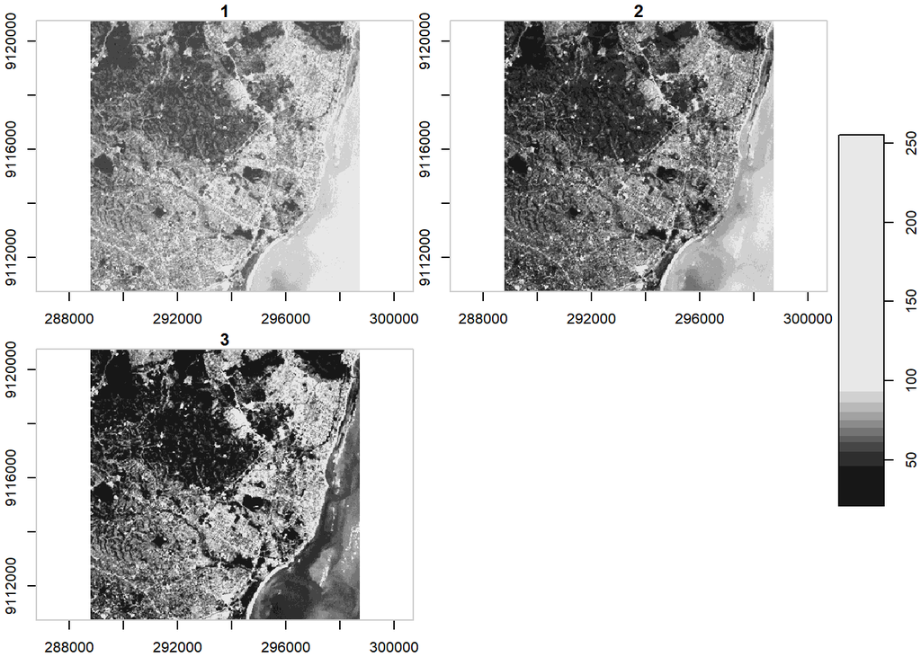

```r
library(dplyr)
img_s1  <-   img %>% slice("band", 1:3)

plot(img_s1, axes = T)
```

Segundo ejemplo, extracción de las columnas 50 a 100, líneas 20 a 60 de las bandas 4 a 6 (infrarrojo).

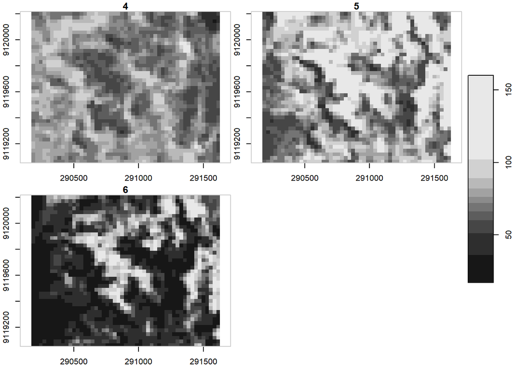

```r
img_s2 <- img        %>%
  slice("x", 50:100) %>%
  slice("y", 20:60)  %>%
  slice("band", 4:6)

plot(img_s2, axes = T)
```

### Ejercicio de aplicación: Calculo del índice NVDI

El Índice de Vegetación por Diferencia Normalizada (NVDI), es una aplicación de imagenes de sensores remotos muy usada en estudios del paisaje terrestre, permite comprender la situación de la cobertura vegetal, analizar la situación de terrreno actual o pasada, biomasa entre otras.

Este índice es obtenido a partir de la combinación de la bandas 3 y 4 (rojo e infrarrojo cercano) en imagenes del satélite Landsat ETm7.

$$NVDI = {{NIR - RED} \over {NIR + RED}}$$

Vamos calcular el índice usando las bandas sin corrección, o sea con los niveles digitales y sin corrección de reflectancia con el fin de simplificar el proceso.

Después del calculo, vamos inspeccionar el objeto, crear una escala de colores entre el azul y el verde y finalmente visualizar el índice.

```r
nvdi = (img[ , , , 4] - img[, , , 3])/
       (img[ , , , 4] + img[, , , 3])

nvdi # inspección del objeto creado
```

```
## stars object with 3 dimensions and 1 attribute
## attribute(s):
##   L7_ETMs.tif
##  Min.   :-0.75342
##  1st Qu.:-0.20301
##  Median :-0.06870
##  Mean   :-0.06432
##  3rd Qu.: 0.18667
##  Max.   : 0.58667
## dimension(s):
##      from  to  offset delta                       refsys point values
## x       1 349  288776  28.5 UTM Zone 25, Southern Hem... FALSE   NULL [x]
## y       1 352 9120761 -28.5 UTM Zone 25, Southern Hem... FALSE   NULL [y]
## band    4   4      NA    NA                           NA    NA   NULL
```

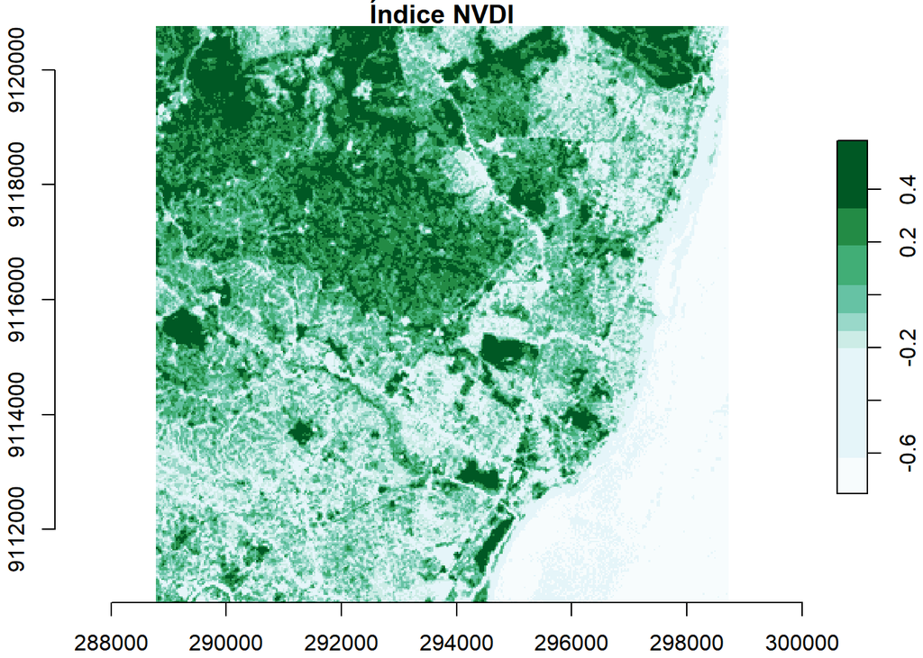

```r
cols <- RColorBrewer::brewer.pal(8, "BuGn") # escala de colores

# visualización
plot(nvdi,
     axes = T,
     col  = cols,
     main = "Índice NVDI")
```

Versión 1 de 2020-12-11 - Año Covid